# Lecture 21: Zero Knowledge Proofs

### Announcements

- Please pick up your card
- Reading Assessment 11 is due **Tuesday** at 6pm on Gradescope
- Course evaluations are now open

### Learning outcomes

By the end of today’s lecture, you will learn:

- What it means to convince someone that a statement is true, without revealing the reason why
- How to build a zero knowledge proof for Sudoku puzzles, and why this simple result extends to build a proof of any efficiently-checkable claim

## 21.1 Motivating question

Secure multi-party computation (MPC) solves a seemingly-impossible problem:

> Many people, each with their own private data that they do not want to share, can still **compute** data analysis collaboratively and only reveal the result!

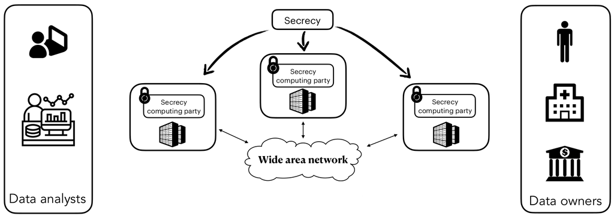

Today, we will study **zero knowledge proofs**. They solve another seemingly-impossible problem:

> A prover can **convince** a verifier that a statement is true, without revealing the evidence or reason why!

**Example 1.** Two interleaved locks

[figure not shown]

Two padlocks ([image source](https://www.publicdomainpictures.net/en/view-image.php?image=129016))

**Example 2.** Sudoku puzzle

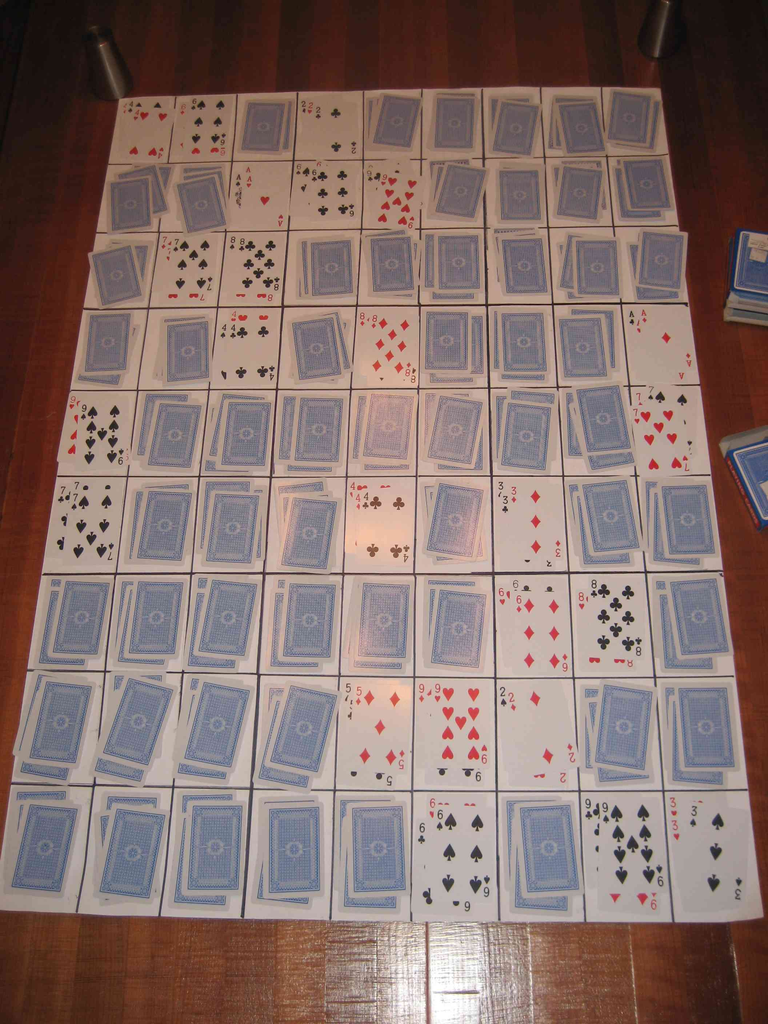

Sudoku proof with playing cards ([image source: Moni Naor](https://www.wisdom.weizmann.ac.il/~naor/PAPERS/SUDOKU_DEMO/))

**Interactive question.** Which part of the demonstration from last week’s lab convinces you that the Sudoku puzzle has a valid solution?

1. When the TF placed cards face-down on the table
2. When the TF offered you the option to pick any row, column, or subgrid
3. When the TF shuffled the cards in the chosen row, column, or subgrid
4. When the TF revealed the cards Ace through 9 (in some order)

### A dramatic claim

There exists a zero knowledge proof for *any* statement!

…well, at least for any statement that can be efficiently checked by a computer, if someone gave you a potential solution. These are called “NP statements.”

So here are some data science examples of statements that can be proved in zero knowledge.

| Example | Application |
| --- | --- |
| I know the password corresponding to username `bob123` | Can be used for authentication to a website |
| The age on my government-issued ID is $\geq$ 21 | Can be used to enter a bar, without revealing all of the data on your identification card |
| I have a database that satisfies a particular predicate | Can be used to audit a dataset without the need for full transparency |
| I have enough money in my account to cover a financial transaction | This will be the basis for privacy-preserving cryptocurrencies |

Let’s try to learn some lessons from the examples we have seen so far.

**Question.** What characteristics do all of these proofs have in common?

- There are two parties: a prover and a verifier
- The prover performs at least some actions that the verifier does **not** directly observe
- The actions are randomized, and there may be some (small!) probability that the proof is incorrect

## 21.2 The idea of ZK proofs

A zero knowledge proof is a protocol involving two parties: a *prover* and a *verifier*.

(Rather than calling the parties Alice and Bob, typically the parties are called Peggy and Victor.)

| Prover Peggy$(x, w)$ |  | Verifier Victor$(x)$ |
| --- | --- | --- |
|  | $\begin{array}{c} \underset{\longleftarrow}{\pi} \\ \longrightarrow \\ \vdots \\ \longrightarrow \end{array}$ |  |
|  |  | output: *Accept* or *Reject* |

Before the protocol starts:

- There is a claimed **statement** $x$ (i.e., the Sudoku puzzle) that is common knowledge: both the prover Peggy and verifier Victor know it
- The prover Peggy also has a **witness** $w$ (i.e., the solution to the Sukodu puzzle)
- Everyone knows an efficiently-computable check program $C(x, w)$ that can determine that the statement is true, given $x$ and $w$ (note that Peggy can run $C$, but Victor cannot since he lacks $w$)

Once the protocol ends: the verifier outputs its judgment about whether to **Accept** or **Reject** the claim that the statement $x$ is true.

Note that the prover has no output. Peggy already knows everything, and she is not trying to learn new information through the interaction. Instead she is just trying to convince the verifier that $x$ is true.

What makes this problem interesting is: *neither party fully trusts the other one*.

- If Victor fully trusted Peggy, he could just take her word that the statement is true. But he wants to be *convinced* that the statement $x$ is true: he cares about the **integrity** of the proof.
- If Peggy fully trusted Victor, then she could send him the solution $w$ and let him check that $C(x, w)$ returns `True`. But Peggy wants to keep $w$ *secret*: she cares about the **confidentiality** of the proof.

The parties can have as many or as few rounds of interaction as the verifier wants. You can think of the interactive dialogue as Victor issuing *challenges* and Peggy providing *responses* to these challenges.

By the end of the interactive conversation, the verifier should be convinced that:

- The statement is true.
- Optionally, Peggy knows the witness $w$ that explains why the statement is true. This is called a *proof of knowledge*.

To understand the difference between a proof and a proof of knowledge: consider the following two statements given a group element $h = g^w$, where $g$ and $h$ are publicly known.

1. There exists a discrete log $w = \log_{g}(h)$
2. I know the discrete log $w = \log_{g}(h)$

### Proving a negative

Victor’s concern about the integrity of the proof is, at a high level, similar to many of the integrity concerns we’ve seen throughout this course: consistency among Byzantine generals, verifiable MPC, etc.

But Peggy’s concern about the confidentiality of the witness is new and strange!

Let’s consider the opposite concept for a moment.

**Question.** If Peggy wanted to be certain that Victor *did learn* why the statement is true, how could she accomplish this goal?

One option is that Peggy could send Victor the witness $w$ and allow Victor to check the proof for himself.

If Peggy is concerned that the message might get lost in transit, Peggy could broadcast $w$ to many servers or post it to a public blockchain, and let Victor download it.

In summary: it is easy to prove that Victor has access to some particular data.

But how do you prove a negative? How do you prove that Victor **does not** have some data?

It is not sufficient to claim that Peggy never sent $w$ to Victor in the interactive protocol. Why is this?

- Perhaps Peggy sent some related data, like $w+1$, which is technically not $w$ but that would allow Victor to deduce $w$ anyway.
- Perhaps Peggy sent the first bit of $w$, which is not the entire secret but is part of it.
- Perhaps Peggy sends nothing about $w$… but her algorithm is vulnerable to being duped in some way. That is: maybe a malicious Victor can find a clever way to force Peggy into making one of the above two mistakes.

Instead, we must find a way to show that Victor has learned **nothing** beyond what he already knew before talking with Peggy.

That is, in the entire conversation, Victor has only learned 1 bit of new information – that the statement $x$ is true. Beyond this, everything else that Peggy sent is random noise.

## 21.3 Defining ZK proofs

| Prover Peggy$(x, w)$ |  | Verifier Victor$(x)$ |
| --- | --- | --- |
|  | $\begin{array}{c} \underset{\longleftarrow}{\pi} \\ \longrightarrow \\ \vdots \\ \longrightarrow \end{array}$ |  |
|  |  | output: *Accept* or *Reject* |

Formally, a zero knowledge proof is an interactive protocol $\pi$ that satisfies three requirements.

1. **Completeness**: every valid proof should be accepted by the verifier.

   In more detail: if the statement $x$ is true and both Peggy and Victor act honestly, then at the end of the protocol Victor will output *True*.
2. **Soundness**: nearly all invalid proofs should be rejected by the verifier.

   In more detail: if the statement $x$ is false and Victor is honest, then it is infeasible for any prover Peggy (even a malicious one) to deceive Victor. That is, Victor will output *False*, except maybe with some probability $\varepsilon$ of making an error and reaching a decision of *True* instead.

An extension of this requirement, called **knowledge soundness**, states that:

> if Peggy can convince Victor to accept the proof, then she must have a witness $w$ that explains why the statement is true.

I am not going to provide a rigorous definition of knowledge soundness in this class.

3. **Zero knowledgeness**: if the statement $x$ is true and Peggy is honest, then it is infeasible for any verifier Victor (even a malicious one) to learn anything from the proof beyond the fact that the statement is true.

### Cryptographic simulation

One of the formative achievements in modern cryptography is to devise a way to formalize this claim – that is, to prove a negative.

Here is how it works. The main insight is to create a new computer program called the **simulator** $S$.

- The simulator is a figment of Victor’s imagination – it does not really exist
- The simulator’s job is to take on the role of the prover and to forge a proof

Wait hang on, that doesn’t sound right! If a proof can be forged, then it wouldn’t be sound!

To resolve this conundrum, we only insist that the simulator forge a proof back to Victor himself.

- The simulator will take on the role of the prover, and it will interact with Victor
- Whenever Victor issues a challenge, the simulator will respond to it too, just like the real prover does

So we can imagine two scenarios:

1. Victor is talking to a real prover Peggy (who has a witness).

   | Prover Peggy$(x, w)$ |  | Verifier Victor$(x)$ |
   | --- | --- | --- |
   |  | $\begin{array}{c} \underset{\longleftarrow}{\pi_\text{Real}} \\ \longrightarrow \\ \vdots \\ \longrightarrow \end{array}$ |  |
   |  |  | output: *Accept* or *Reject* |

2. Victor is talking to this imaginary simulator (who doesn’t know the witness).

   | Simulator$(x)$ |  | Verifier Victor$(x)$ |
   | --- | --- | --- |
   |  | $\begin{array}{c} \underset{\longleftarrow}{\pi_\text{Fake}} \\ \longrightarrow \\ \vdots \\ \longrightarrow \end{array}$ |  |
   |  |  | output: *Accept* or *Reject* |

Now, we can formalize the **zero knowledgeness** requirement:

> For any verifier $V$ and statement $x$, there exists a simulator $S$ such that it is infeasible to tell the difference between the random variables $\pi_\text{Real}$ and $\pi_\text{Fake}$.

It is easiest to think through the concept of simulation using an example. Let’s go back to our Sudoku puzzle from lab.

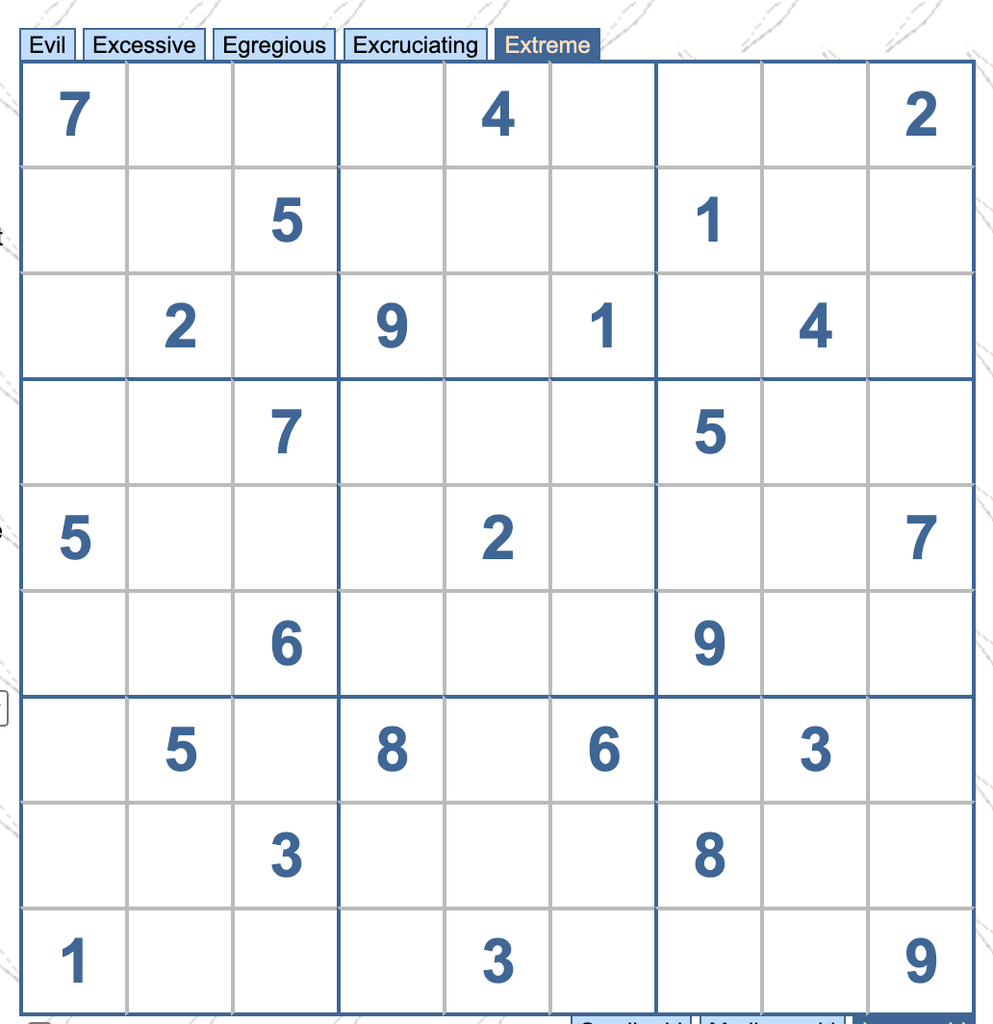

Sudoku puzzle

Every time the verifier Victor issues a challenge to open one row, column, or grid:

- He already “knows” what he is expecting to see: *the numbers 1 through 9, in a random order*
- Hence: it isn’t really the cards themselves that convince Victor that the proof is true

Instead what convinces Victor is that:

- Peggy already committed to the cards beforehand (i.e., placed them facedown and cannot change them later), before Victor’s challenge
- The publicly visible cards correspond to the actual puzzle $x$ that Victor wanted to know whether it is solveable
- Peggy is capable of responding to many challenges from Victor in a consistent way – that is, from the same commitment of the cards

## 21.4 Constructing a ZK proof of Sudoku over the Internet

The zero knowledge proof of a Sudoku puzzle works well in our classroom. But what if Peggy and Victor are not in the same place?

- Suppose Peggy and Victor are communicating via a text messaging program over the Internet
- We will use cryptographic commitments as the digital version of a face-down playing card

Additionally, I’m going to use one more property of Sudoku puzzles: if I permute all of the numbers in the range 1-9 (both the public and secret numbers), then the result is still a Sudoku puzzle.

| Original | 1 | 2 | 3 | 4 | 5 | 6 | 7 | 8 | 9 |
| --- | --- | --- | --- | --- | --- | --- | --- | --- | --- |
| Permuted | 3 | 2 | 7 | 9 | 4 | 5 | 6 | 1 | 8 |

### The protocol

Here is the setup. Both Peggy and Victor know a Sudoku puzzle, and Peggy also knows its solution.

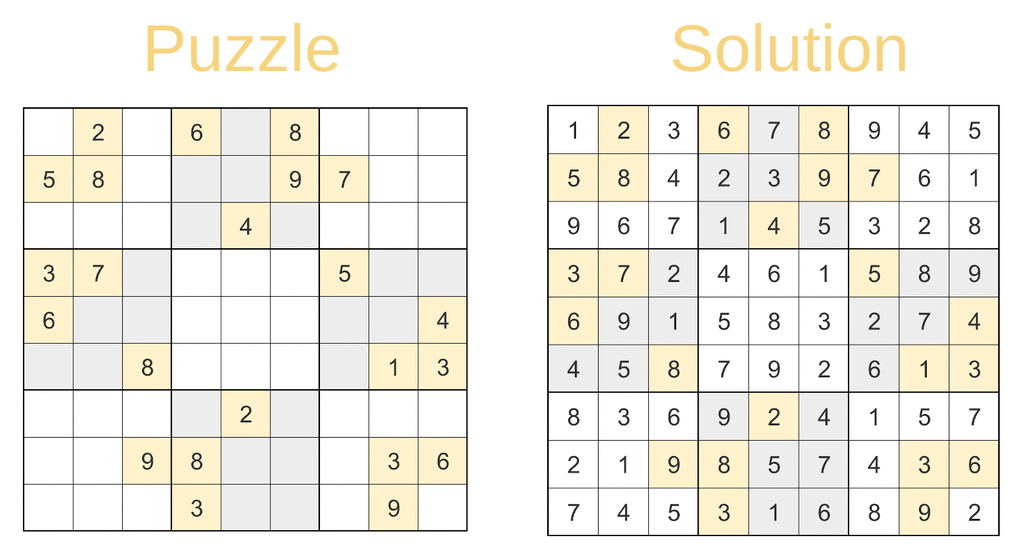

Sudoku puzzle with solution (image source: [Andreas Pogiatzis](https://medium.com/coinmonks/walkthrough-of-an-interactive-zero-knowledge-proof-for-sudoku-puzzle-ac563588f1a8))

**Step 1.** Peggy creates a random new puzzle and its solution, by creating a random permutation of the numbers 1 through 9. (In essence, Peggy is “pre-shuffling” every row, column, and subgrid.)

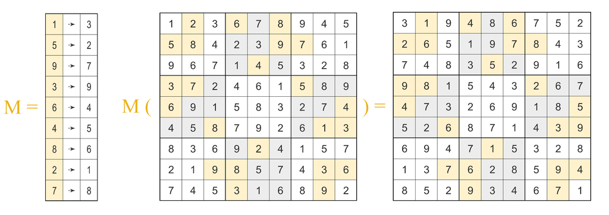

Peggy permutes the puzzle (image source: [Andreas Pogiatzis](https://medium.com/coinmonks/walkthrough-of-an-interactive-zero-knowledge-proof-for-sudoku-puzzle-ac563588f1a8))

**Step 2.** Peggy commits to each cell of the puzzle. (Remember that each commitment needs its own one-time randomness!) She sends all 81 commitments to Victor.

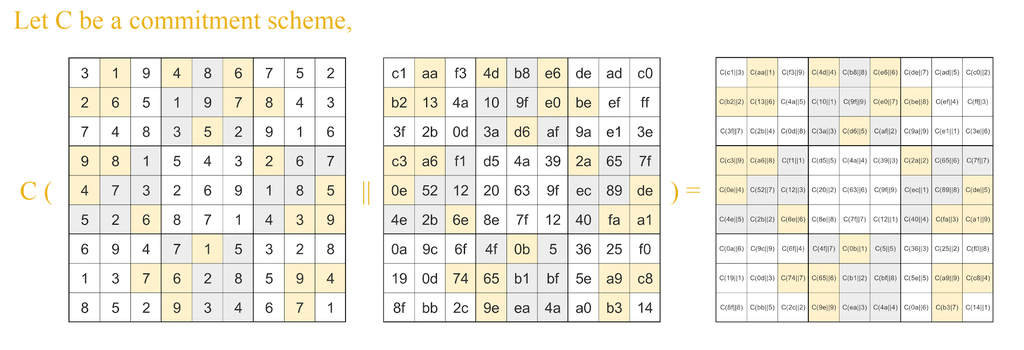

Peggy commits to the entries of the permuted puzzle (image source: [Andreas Pogiatzis](https://medium.com/coinmonks/walkthrough-of-an-interactive-zero-knowledge-proof-for-sudoku-puzzle-ac563588f1a8))

**Step 3.** Victor requests that Peggy do one of the following.

- Open all 9 commitments on a row of Victor’s choice.
- Open all 9 commitments on a column of Victor’s choice.
- Open all 9 commitments on a grid of Victor’s choice.
- Open all of the public (yellow) values and share the permutation $M$ that links the original puzzle with the permuted puzzle.

Note that there are a total of 28 possible actions that Victor can request here.

**Step 4.** Peggy performs the requested action by opening the commitments to the relevant cells, but no others. Victor then checks that the commitments satisfy the desired property.

- If a row, column, or grid was opened: check that the numbers are 1 through 9 in some order.
- If the public values and $M$ are opened, check that the opened puzzle really is a permuted version of the original (public) puzzle.

If so, Victor outputs **Accept**. Otherwise he outputs **Reject**.

### The analysis

Does this proof satisfy the three criteria of a zero knowledge proof? Let’s check.

**Completeness** is the easiest requirement to think about. If Peggy is telling the truth, then her permuted and committed Sudoku puzzle will be correct. Hence, it will satisfy any of the 28 actions that an honest Victor could request.

**Soundness** is a bit more complicated to reason about. Remember that soundness is about catching a malicious prover.

> If the statement $x$ is false and Victor is honest, then it is infeasible for any prover Peggy (even a malicious one) to deceive Victor. That is, Victor will output *False*, except maybe with some probability $\varepsilon$ of making an error and reaching a decision of *True* instead.

If Peggy is lying and the Sudoku puzzle actually has no solution, then:

- Peggy’s permuted & committed puzzle has to be wrong *somewhere* (after all: if it satisfies the rules for all rows, columns, and grids and connects to the real puzzle $x$, then it **is** a valid Sudoku solution!)
- We don’t know which of the 28 conditions Peggy has violated, but it has to be at least one of them

Hence, if the statement $x$ is false, then Victor will catch Peggy with at least probability $\frac{1}{28}$; or in other words, Peggy will get away with cheating with probability at most $\varepsilon = \frac{27}{28} = 0.9643$.

That’s… actually not very satisfying.

**Question.** How can we reduce the soundness error?

*Answer*. We can amplify the soundness via **repetition**.

- Run the proof many times, either in sequence or in parallel
- Each time, Peggy chooses a new permutation $M$ and new commitments for each cell
- Each time, Victor has a chance to catch Peggy in a lie
- If they repeat the protocol $k$ times, then Peggy gets away with cheating with probability $\leq (27/28)^k$

**Interactive question.** If Victor wants to be convinced that the Sudoku puzzle is solveable with probability at least $1 - \frac{1}{2^{128}}$, then how many times $k$ must Peggy and Victor repeat the proof?

1. Between 1 and 10
2. Between 10 and 100
3. Between 100 and 1000
4. Between 1000 and 10,000

*Answer*. If $k = 2440$, then the probability of cheating on all repetitions is less than $1/2^{128}$. We can find this value of $k$ by solving

$$\begin{align*}
(27/28)^k &= 2^{-128} \qquad \text{now take the $\log_2$ of both sides}\\
k \cdot \log_2(27/28) &= -128 \qquad \text{using the fact that $\log_2(a^b) = b \cdot \log_2(a)$}\\
k &= -128 / \log_2(27/28)
\end{align*}$$

Admittedly, this requires that Peggy and Victor construct, exchange, and open a lot of Sudoku puzzles. At least computing power and network communication are cheap nowadays!

**Zero knowledgeness** is also a subtle point to reason about. Remember that our goal is to construct a *simulator* whose actions look identical to the real prover Peggy’s work in the real world.

| Simulator$(x)$ |  | Verifier Victor$(x)$ |
| --- | --- | --- |
|  | $\begin{array}{c} \underset{\longleftarrow}{\pi_\text{Fake}} \\ \longrightarrow \\ \vdots \\ \longrightarrow \end{array}$ |  |
|  |  | output: *Accept* or *Reject* |

But also: the simulator isn’t real; it’s just a figment of Victor’s mind. And as a result, the simulator already “knows” the decisions that Victor will take – specifically, which of the 28 checks Victor will choose to test Peggy on.

As a result, the simulator (who does not know the Sudoku solution $w$) can interact with Victor by using a fake puzzle that is *only* correct on the opened commitments, but nowhere else.

To make this claim rigorous, let’s change the protocol slightly by adding a new round of interaction at the start of the zero knowledge proof.

1. **Victor commits to his choice of action in step 3 below**.
2. Peggy sends all 81 commitments to the permuted puzzle to Victor.
3. Victor **opens his commitment from step 1 and** requests that Peggy do one of 28 specified actions.
4. Peggy performs the requested action by opening the commitments to the relevant cells. Victor checks that they satisfy the desired property.

Also when we say that the simulator and Victor are the same party, what we mean formally is that they are both just computer programs that are controlled by the same entity. We will see in a second how to use this property.

Here’s how the simulator works.

- Since the simulator doesn’t know the real solution $w$, it makes up a random Sudoku puzzle that has no connection to reality.
- Next, the simulator interacts with Victor to perform steps 1, 2, and 3 of the protocol. So far, the simulator has only sent commitments to the fake puzzle, but commitments are hiding so Victor cannot tell that the simulator is using a fake puzzle. (Victor would find out if we continued on to step 4, though.)
- From step 3 of the proof, the simulator has now learned which action Victor will use as his test. Now the simulator **rewinds Victor’s state** back to the end of step 1, creates a new puzzle that is correct on the desired row/column/grid/public values, and completes the rest of the proof in the same way as the honest prover would.

That’s it! This “rewinding” trick is what makes the analysis work. This is how we formalize the intuitive claim from before that:

> It isn’t really the cards themselves that convince Victor that the proof is true. Instead what convinces Victor is that Peggy already committed to the cards beforehand.

## 21.5 From Sudoku to Everything

**Question.** If we have a digital way to prove that a Sudoku puzzle can be solved, what else can we do with this?

*Answer*. Amazingly, you can do quite a lot!

- If you take a complexity theory course, you will learn that Sudoku puzzles (if you extend them to be larger than $9 \times 9$ have the property of being **NP-complete**
- In simple terms, what this means is that you can take **any** problem that has an efficiently-computable check program $C(x, w)$ and convert it into a Sudoku puzzle, so that the original problem is true if and only if the corresponding Sudoku puzzle is true

The punchline is that: you can prove *any computational statement* in zero knowledge!

- Knowing the password corresponding to username `bob123`
- Revealing only that my government-issued ID has age $\geq$ 21
- Auditing a dataset, and showing that it satisfies a particular predicate
- Proving that a cryptocurrency account has sufficient funds to cover a financial transaction

However, the approach we took today may not be the most efficient way to construct a proof. In particular, this approach (of turning any problem into a Sudoku puzzle) is inefficient in at least three metrics.

1. **Computation**: doing this reduction from a general problem to a Sudoku puzzle is computationally intensive; it would be better to find new ways to prove directly the statements that are of interest to us
2. **Interaction**: the proof we constructed today only convinces a single verifier Victor; if Peggy wants to convince someone else then she will have to start all over again
3. **Communication**: in order to reduce the soundness error, the digital Sudoku proof must create thousands of permuted/committed Sudoku puzzles and send them all over the Internet

Next time: we will discuss zero knowledge proofs that are faster, non-interactive, and succinct.